# Esame Modelli Statistici

Nicola Zucchia

2023-02-15

## Esplorazione dei dati

Questo lavoro consiste nell’analisi dei dati reperibili al link https://www.kaggle.com/datasets/hellbuoy/car-price-prediction?select=CarPrice_Assignment.csv e la costruzione di un modello di regressione lineare multipla.

Il primo passo consiste nel caricare i dati e darne una panoramica con le prime righe del dataset.

```r
d <- read.csv("R Files/CarPrice_Assignment.csv", header = TRUE)
head(d)
```

```
##   car_ID symboling                  CarName fueltype aspiration doornumber
## 1      1         3       alfa-romero giulia      gas        std        two
## 2      2         3      alfa-romero stelvio      gas        std        two
## 3      3         1 alfa-romero Quadrifoglio      gas        std        two
## 4      4         2              audi 100 ls      gas        std       four
## 5      5         2               audi 100ls      gas        std       four
## 6      6         2                 audi fox      gas        std        two
##       carbody drivewheel enginelocation wheelbase carlength carwidth carheight
## 1 convertible        rwd          front      88.6     168.8     64.1      48.8
## 2 convertible        rwd          front      88.6     168.8     64.1      48.8
## 3   hatchback        rwd          front      94.5     171.2     65.5      52.4
## 4       sedan        fwd          front      99.8     176.6     66.2      54.3
## 5       sedan        4wd          front      99.4     176.6     66.4      54.3
## 6       sedan        fwd          front      99.8     177.3     66.3      53.1
##   curbweight enginetype cylindernumber enginesize fuelsystem boreratio stroke
## 1       2548       dohc           four        130       mpfi      3.47   2.68
## 2       2548       dohc           four        130       mpfi      3.47   2.68
## 3       2823       ohcv            six        152       mpfi      2.68   3.47
## 4       2337        ohc           four        109       mpfi      3.19   3.40
## 5       2824        ohc           five        136       mpfi      3.19   3.40
## 6       2507        ohc           five        136       mpfi      3.19   3.40
##   compressionratio horsepower peakrpm citympg highwaympg price
## 1              9.0        111    5000      21         27 13495
## 2              9.0        111    5000      21         27 16500
## 3              9.0        154    5000      19         26 16500
## 4             10.0        102    5500      24         30 13950
## 5              8.0        115    5500      18         22 17450
## 6              8.5        110    5500      19         25 15250
```

Il dataset in questione riporta varie informazioni riguardo lo stato, le caratteristiche fisiche e meccaniche e il prezzo di varie vetture. Lo scopo di questa analisi è quella di fornire un modello di regressione lineare multipla che veda il prezzo come variabile risposta: si cerca dunque di esprimere al meglio come le altre variabili influenzino il prezzo.

Si descrivono in sintesi le variabili contenute nel dataset:

- car_ID : variabile contatore per l’identificabilità delle righe all’interno del database
- symboling : variabile segnata come numerica per indicare il livello di sicurezza della vettura
- CarName : variabile qualitativa per il nome del modello di auto
- fueltype : variabile qualitativa per il tipo di combustibile
- aspiration : variabile qualitative per il tipo di aspirazione del motore
- doornumber : variabile qualitativa per il numero di portiere dell’auto
- carbody : variabile qualitativa per la struttura della vettura
- drivewheel : variabile qualitativa per il tipo di ruote motrici
- enginelocation : variabile qualitativa per la locazione del motore nell’auto
- wheelbase : variabile quantitativa per il passo (def: distanza tra gli assi)
- carlength : variabile quantitativa per la lunghezza della vettura
- carwidth : variabile quantitativa per la larghezza della vettura
- carheight : variabile quantitativa per l’altezza della vettura
- curbweight : variabiel quantitativa per il peso a vuoto della vettura
- enginetype : variabile qualitativa per il tipo del motore
- cylindernumber : variabile qualitativa per il numero dei cilindri del motore
- enginesize : variabile quantitativa per la grandezza del motore
- fuelsystem : variabile qualitativa per la modalità di alimentazione del motore
- boreratio : variabile quantitativa per il rapporto alesaggio (riguarda la dimensione del motore)
- stroke : variabile quantitativa per il movimento del pistone
- compressionratio : variabile quantitativa per il rapporto tra il volume del cilindro col pistone alla base rispetto a quello alla sommità
- horsepower : variabile quantitativa per il numero di cavalli
- peakrpm : variabile quantitativa per il numero massimo di giri del motore
- citympg : variabile quantitativa per il consumo in città (miles-per-gallon)
- highwaympg : variabile quantitativa per il consumo in autostrada (miles-per-gallon)
- price : variabile quantitativa per il prezzo

Ai fini dell’analisi, car_ID risulta essere inutile, di conseguenza viene eliminata.

```r
d <- d[,-c(1)]
```

Un primo accertamento che viene fatto è la verifica dell’assenza di NA.

```r
sum(is.na(d))
```

```
## [1] 0
```

Un altro passaggio preliminare consiste nel trasformare le variabili categoriali in fattori.

```r
d$CarName <- as.factor(d$CarName)
d$fueltype <- as.factor(d$fueltype)
d$aspiration <- as.factor(d$aspiration)
d$doornumber <- as.factor(d$doornumber)
d$carbody <- as.factor(d$carbody)
d$drivewheel <- as.factor(d$drivewheel)
d$enginelocation <- as.factor(d$enginelocation)
d$enginetype <- as.factor(d$enginetype)
d$cylindernumber <- as.factor(d$cylindernumber)
d$fuelsystem <- as.factor(d$fuelsystem)
```

Il dataset così ottenuto è pronto per l’analisi e della forma seguente.

```r
str(d)
```

```
## 'data.frame':    205 obs. of  25 variables:
##  $ symboling       : int  3 3 1 2 2 2 1 1 1 0 ...
##  $ CarName         : Factor w/ 147 levels "alfa-romero giulia",..: 1 3 2 4 5 9 5 7 6 8 ...
##  $ fueltype        : Factor w/ 2 levels "diesel","gas": 2 2 2 2 2 2 2 2 2 2 ...
##  $ aspiration      : Factor w/ 2 levels "std","turbo": 1 1 1 1 1 1 1 1 2 2 ...
##  $ doornumber      : Factor w/ 2 levels "four","two": 2 2 2 1 1 2 1 1 1 2 ...
##  $ carbody         : Factor w/ 5 levels "convertible",..: 1 1 3 4 4 4 4 5 4 3 ...
##  $ drivewheel      : Factor w/ 3 levels "4wd","fwd","rwd": 3 3 3 2 1 2 2 2 2 1 ...
##  $ enginelocation  : Factor w/ 2 levels "front","rear": 1 1 1 1 1 1 1 1 1 1 ...
##  $ wheelbase       : num  88.6 88.6 94.5 99.8 99.4 ...
##  $ carlength       : num  169 169 171 177 177 ...
##  $ carwidth        : num  64.1 64.1 65.5 66.2 66.4 66.3 71.4 71.4 71.4 67.9 ...
##  $ carheight       : num  48.8 48.8 52.4 54.3 54.3 53.1 55.7 55.7 55.9 52 ...
##  $ curbweight      : int  2548 2548 2823 2337 2824 2507 2844 2954 3086 3053 ...
##  $ enginetype      : Factor w/ 7 levels "dohc","dohcv",..: 1 1 6 4 4 4 4 4 4 4 ...
##  $ cylindernumber  : Factor w/ 7 levels "eight","five",..: 3 3 4 3 2 2 2 2 2 2 ...
##  $ enginesize      : int  130 130 152 109 136 136 136 136 131 131 ...
##  $ fuelsystem      : Factor w/ 8 levels "1bbl","2bbl",..: 6 6 6 6 6 6 6 6 6 6 ...
##  $ boreratio       : num  3.47 3.47 2.68 3.19 3.19 3.19 3.19 3.19 3.13 3.13 ...
##  $ stroke          : num  2.68 2.68 3.47 3.4 3.4 3.4 3.4 3.4 3.4 3.4 ...
##  $ compressionratio: num  9 9 9 10 8 8.5 8.5 8.5 8.3 7 ...
##  $ horsepower      : int  111 111 154 102 115 110 110 110 140 160 ...
##  $ peakrpm         : int  5000 5000 5000 5500 5500 5500 5500 5500 5500 5500 ...
##  $ citympg         : int  21 21 19 24 18 19 19 19 17 16 ...
##  $ highwaympg      : int  27 27 26 30 22 25 25 25 20 22 ...
##  $ price           : num  13495 16500 16500 13950 17450 ...
```

Si nota come CarName abbia 147 livelli, un numero spropositato anche vista l’ampiezza del dataset. Viene dunque rimossa.

```r
d <- d[,-c(2)]
```

La variabile symboling, secondo il dizionario fornito assieme ai dati, è una variabile categoriale assegnata per indicare il livello di di sicurezza dell’auto. +3 indica maggiore rischio, -3 più sicurezza. Viene dunque anch’essa convertita in fattore.

```r
d$symboling <- as.factor(d$symboling)
```

## Analisi della variabile risposta

Si desidera verificare la distribuzione di price.

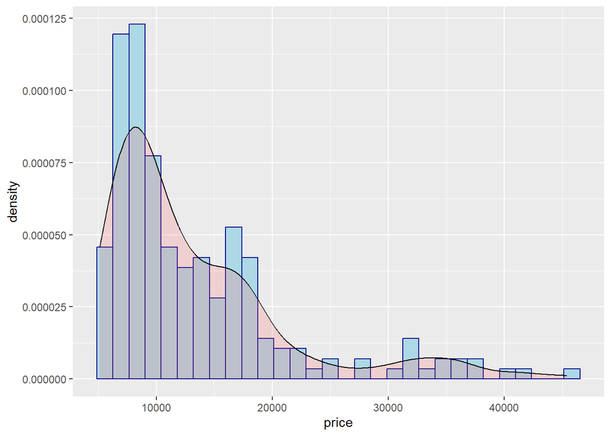

```r
library(ggplot2)

ggplot(d, aes(x = price)) +
 geom_histogram(aes(y = after_stat(density)), colour = "darkblue", fill = "lightblue") +
 geom_density(alpha = .2, fill = "#FF6666")
```

Chiaramente non è normale. Si procede con una trasformazione logaritmica.

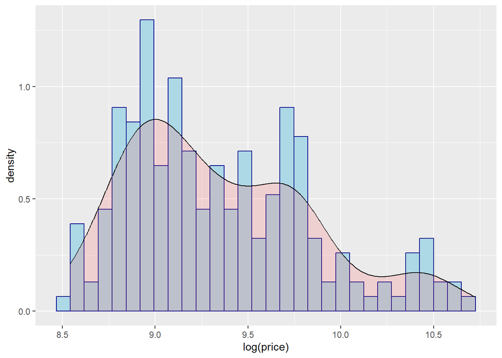

```r
ggplot(d, aes(x = log(price))) +
 geom_histogram(aes(y = after_stat(density)), colour = "darkblue", fill = "lightblue") +
 geom_density(alpha = .2, fill = "#FF6666")
```

La trasformazione logaritmica, sebbene non renda la variabile risposta normale, sembra perlomeno avere un comportamento più regolare e simmetrico. Si tenga anche presente che il dataset conta 205 osservazioni della variabile, e quindi attendersi una forma nitida è improbabile.

## Altre variabili

Per prima cosa, si guarda alla matrice di correlazione per le variabili quantitative per avere un’idea di quali possano influenzare di più la variabile risposta e di quali possano causare multicollinearità.

```r
corrs <- cor(d[,c(8,9,10,11,12,15,17,18,19,20,21,22,23,24)])
round(corrs, digits = 2)
```

```
##                  wheelbase carlength carwidth carheight curbweight enginesize
## wheelbase             1.00      0.87     0.80      0.59       0.78       0.57
## carlength             0.87      1.00     0.84      0.49       0.88       0.68
## carwidth              0.80      0.84     1.00      0.28       0.87       0.74
## carheight             0.59      0.49     0.28      1.00       0.30       0.07
## curbweight            0.78      0.88     0.87      0.30       1.00       0.85
## enginesize            0.57      0.68     0.74      0.07       0.85       1.00
## boreratio             0.49      0.61     0.56      0.17       0.65       0.58
## stroke                0.16      0.13     0.18     -0.06       0.17       0.20
## compressionratio      0.25      0.16     0.18      0.26       0.15       0.03
## horsepower            0.35      0.55     0.64     -0.11       0.75       0.81
## peakrpm              -0.36     -0.29    -0.22     -0.32      -0.27      -0.24
## citympg              -0.47     -0.67    -0.64     -0.05      -0.76      -0.65
## highwaympg           -0.54     -0.70    -0.68     -0.11      -0.80      -0.68
## price                 0.58      0.68     0.76      0.12       0.84       0.87
##                  boreratio stroke compressionratio horsepower peakrpm citympg
## wheelbase             0.49   0.16             0.25       0.35   -0.36   -0.47
## carlength             0.61   0.13             0.16       0.55   -0.29   -0.67
## carwidth              0.56   0.18             0.18       0.64   -0.22   -0.64
## carheight             0.17  -0.06             0.26      -0.11   -0.32   -0.05
## curbweight            0.65   0.17             0.15       0.75   -0.27   -0.76
## enginesize            0.58   0.20             0.03       0.81   -0.24   -0.65
## boreratio             1.00  -0.06             0.01       0.57   -0.25   -0.58
## stroke               -0.06   1.00             0.19       0.08   -0.07   -0.04
## compressionratio      0.01   0.19             1.00      -0.20   -0.44    0.32
## horsepower            0.57   0.08            -0.20       1.00    0.13   -0.80
## peakrpm              -0.25  -0.07            -0.44       0.13    1.00   -0.11
## citympg              -0.58  -0.04             0.32      -0.80   -0.11    1.00
## highwaympg           -0.59  -0.04             0.27      -0.77   -0.05    0.97
## price                 0.55   0.08             0.07       0.81   -0.09   -0.69
##                  highwaympg price
## wheelbase             -0.54  0.58
## carlength             -0.70  0.68
## carwidth              -0.68  0.76
## carheight             -0.11  0.12
## curbweight            -0.80  0.84
## enginesize            -0.68  0.87
## boreratio             -0.59  0.55
## stroke                -0.04  0.08
## compressionratio       0.27  0.07
## horsepower            -0.77  0.81
## peakrpm               -0.05 -0.09
## citympg                0.97 -0.69
## highwaympg             1.00 -0.70
## price                 -0.70  1.00
```

Si da un’alternativa grafica di tale matrice.

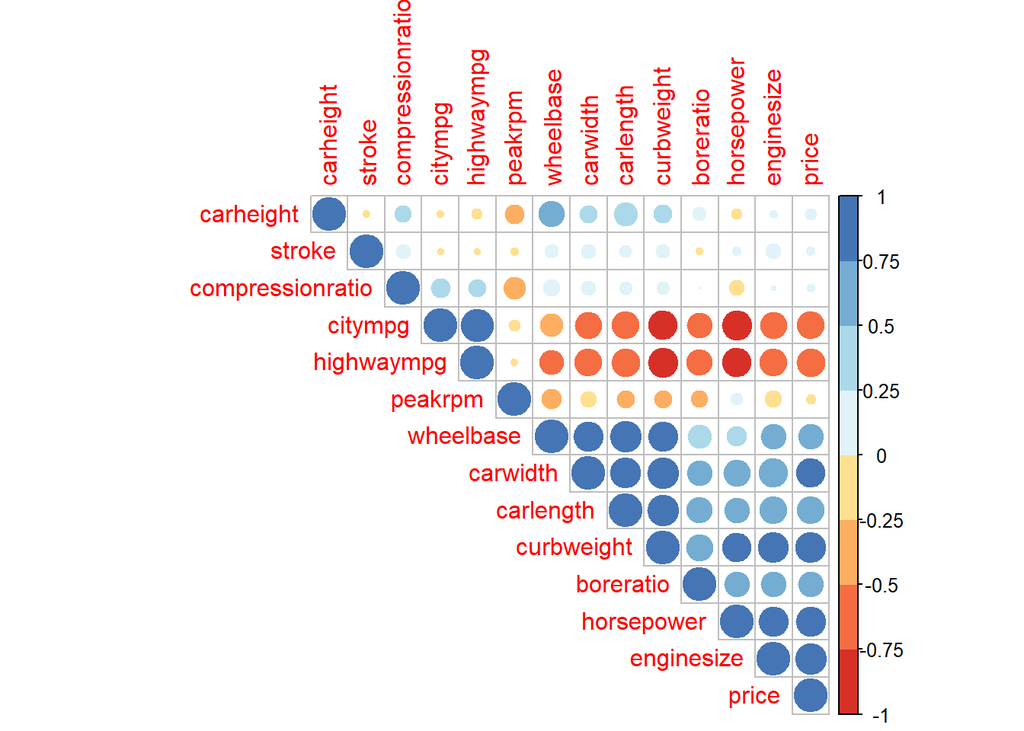

```r
library(corrplot)
library(RColorBrewer)
corrplot(corrs, type="upper", order="hclust", col=brewer.pal(n = 8, name = "RdYlBu"))
```

Da questa analisi si evince come le variabili quantitative maggiormente correlate con price sono: enginesize, curbweight, horsepower, carwidth, carlength, wheelbase, boreratio (positivamente); citympg, highwaympg (negativamente).

Si svolge un’attenta valutazione della multicollinearità.

```r
fitC <- lm(price ~ citympg, data=d)
summary(fitC)
```

```
##
## Call:
## lm(formula = price ~ citympg, data = d)
##
## Residuals:
##    Min     1Q Median     3Q    Max
##  -9215  -3315  -1770   1974  22728
##
## Coefficients:
##             Estimate Std. Error t value Pr(>|t|)
## (Intercept) 34395.44    1625.03   21.17   <2e-16 ***
## citympg      -837.40      62.38  -13.42   <2e-16 ***
## ---
## Signif. codes:  0 '***' 0.001 '**' 0.01 '*' 0.05 '.' 0.1 ' ' 1
##
## Residual standard error: 5829 on 203 degrees of freedom
## Multiple R-squared:  0.4703, Adjusted R-squared:  0.4676
## F-statistic: 180.2 on 1 and 203 DF,  p-value: < 2.2e-16
```

```r
fitH <- lm(price ~ highwaympg, data=d)
summary(fitH)
```

```
##
## Call:
## lm(formula = price ~ highwaympg, data = d)
##
## Residuals:
##    Min     1Q Median     3Q    Max
##  -8698  -3519  -1302   1114  20956
##
## Coefficients:
##             Estimate Std. Error t value Pr(>|t|)
## (Intercept) 38162.86    1838.18   20.76   <2e-16 ***
## highwaympg   -809.27      58.34  -13.87   <2e-16 ***
## ---
## Signif. codes:  0 '***' 0.001 '**' 0.01 '*' 0.05 '.' 0.1 ' ' 1
##
## Residual standard error: 5738 on 203 degrees of freedom
## Multiple R-squared:  0.4866, Adjusted R-squared:  0.4841
## F-statistic: 192.4 on 1 and 203 DF,  p-value: < 2.2e-16
```

```r
fitCH <- lm(price ~ citympg + highwaympg, data=d)
summary(fitCH)
```

```
##
## Call:
## lm(formula = price ~ citympg + highwaympg, data = d)
##
## Residuals:
##    Min     1Q Median     3Q    Max
##  -8792  -3558  -1368   1175  20755
##
## Coefficients:
##             Estimate Std. Error t value Pr(>|t|)
## (Intercept)  37607.0     2013.6  18.676  < 2e-16 ***
## citympg       -176.1      258.7  -0.681  0.49685
## highwaympg    -646.8      245.7  -2.632  0.00914 **
## ---
## Signif. codes:  0 '***' 0.001 '**' 0.01 '*' 0.05 '.' 0.1 ' ' 1
##
## Residual standard error: 5746 on 202 degrees of freedom
## Multiple R-squared:  0.4878, Adjusted R-squared:  0.4827
## F-statistic:  96.2 on 2 and 202 DF,  p-value: < 2.2e-16
```

```r
d <- d[,-c(22)]
```

Le altre combinazioni di variabili che possono portare a multicollinearità sulla base del coefficiente di correlazione lineare sono:

- wheelbase, carlength, carwidth e curbweight tra di loro;
- enginesize, horsepower e curbweight tra di loro;
- citympg, highwaympg e horsepower tra di loro.

La presenza ridondante di curbweight e la sua alta correlazione con price potrebbe spiegare di per sè gran parte della variabilità senza però darci tante informazioni e rischiando multicollinearità con le altre variabili. Di conseguenza, si decide di tralasciarla. (in Italiano, il peso a vuoto della macchina).

```r
d <- d[,-c(12)]
```

Durante la costruzione dei modelli, si controllerà se verranno incluse più variabili che possano portare multicollinearità. In tal caso, si escluderà quella meno significativa.

Per quanto riguarda le variabili categoriali, si esegue un ANOVA test.

```r
# definisco una funzione che, dato in input la variabile fattore, ritorna il p-value dell'ANOVA test
anova.p.calc <- function(v) {
  anova.result <- aov(d$price ~ v)
  a.summary <- summary(anova.result)
  p.value <- a.summary[[1]]$`Pr(>F)`[1]
  return (p.value)
}

# applico la funzione a ogni colonna del dataset corrispondente a fattori e stampo l'indice solo se il test rifiuta l'ipotesi nulla di uguaglianza delle medie (p-value < 0.05)
fac.vars <- c(1,2,3,4,5,6,7,12,13,15)
sig.cat <- numeric()
not.sig.cat <- numeric()
for (i in fac.vars) {
  curr.p.val <- anova.p.calc(d[,c(i)])
  if (curr.p.val < 0.05) {
    sig.cat <- c(sig.cat,i)
  }
  else {
    not.sig.cat <- c(not.sig.cat,i)
  }
}
sig.cat
```

```
## [1]  1  3  5  6  7 12 13 15
```

```r
not.sig.cat
```

```
## [1] 2 4
```

Elimino dal dataset le variabili categoriali non significative, onde evitare rumore nella costruzione del modello.

```r
d <- d[,-c(not.sig.cat)]
```

```r
table(d$enginetype)
```

```
##
##  dohc dohcv     l   ohc  ohcf  ohcv rotor
##    12     1    12   148    15    13     4
```

```r
table(d$cylindernumber)
```

```
##
##  eight   five   four    six  three twelve    two
##      5     11    159     24      1      1      4
```

```r
table(d$fuelsystem)
```

```
##
## 1bbl 2bbl 4bbl  idi  mfi mpfi spdi spfi
##   11   66    3   20    1   94    9    1
```

Si procede eliminando le righe dei livelli contenenti una sola osservazione. Si elimina anche “two” per cylindernumber, altrimenti i modelli lineari computano un NA come coefficiente per quel livello.

```r
d <- d[d$enginetype != "dohcv", ]
d <- d[d$cylindernumber != "three", ]
d <- d[d$cylindernumber != "twelve", ]
d <- d[d$cylindernumber != "two", ]
d <- d[d$fuelsystem != "mfi", ]
d <- d[d$fuelsystem != "spfi", ]
d$enginetype <- droplevels(d$enginetype)
d$cylindernumber <- droplevels(d$cylindernumber)
d$fuelsystem <- droplevels(d$fuelsystem)
```

Vediamo come sono ora i boxplot.

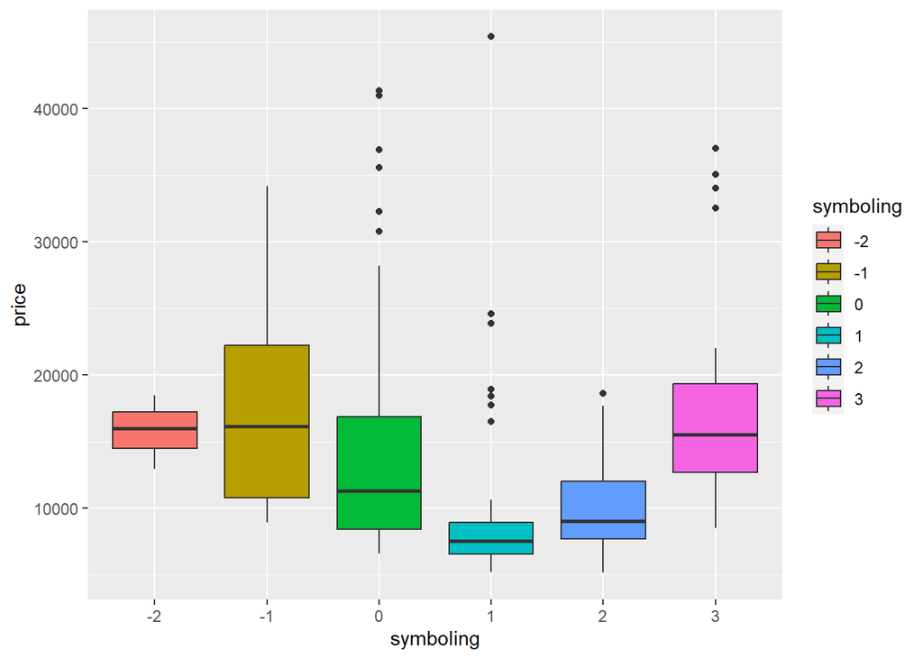

```r
par(mfrow=c(3,3))
ggplot(d, aes(x = symboling, y = price, fill = symboling)) +
       geom_boxplot( )
```

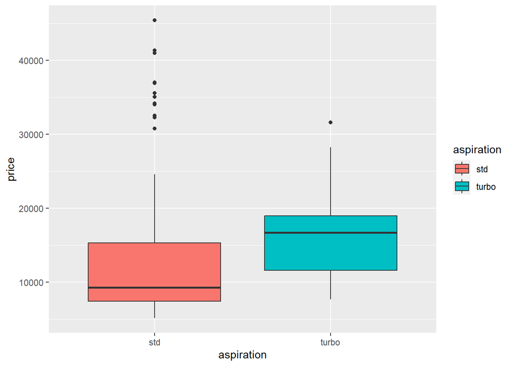

```r
ggplot(d, aes(x = aspiration, y = price, fill = aspiration)) +
       geom_boxplot( )
```

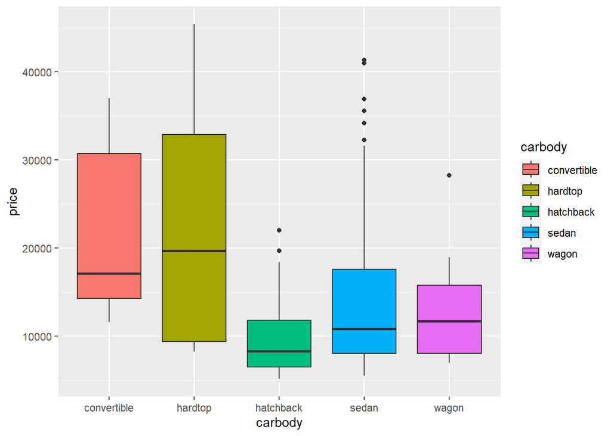

```r
ggplot(d, aes(x = carbody, y = price, fill = carbody)) +
       geom_boxplot( )
```

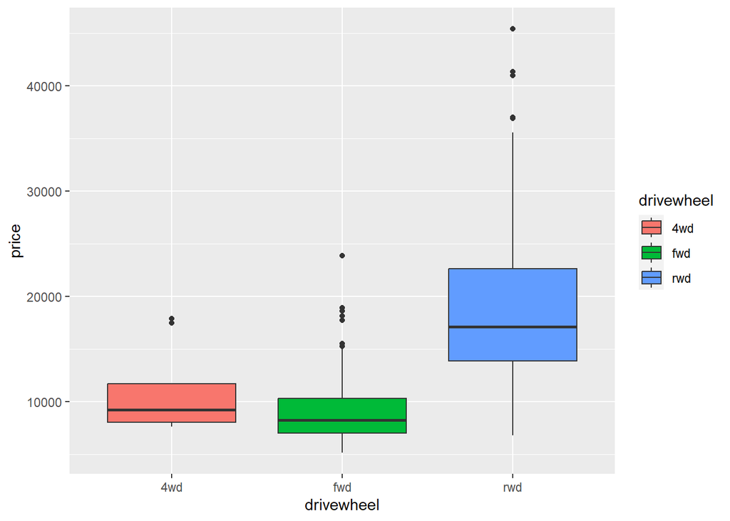

```r
ggplot(d, aes(x = drivewheel, y = price, fill = drivewheel)) +
       geom_boxplot( )
```

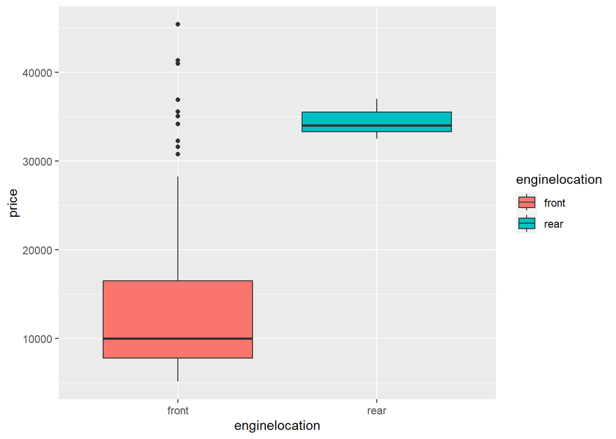

```r
ggplot(d, aes(x = enginelocation, y = price, fill = enginelocation)) +
       geom_boxplot( )
```

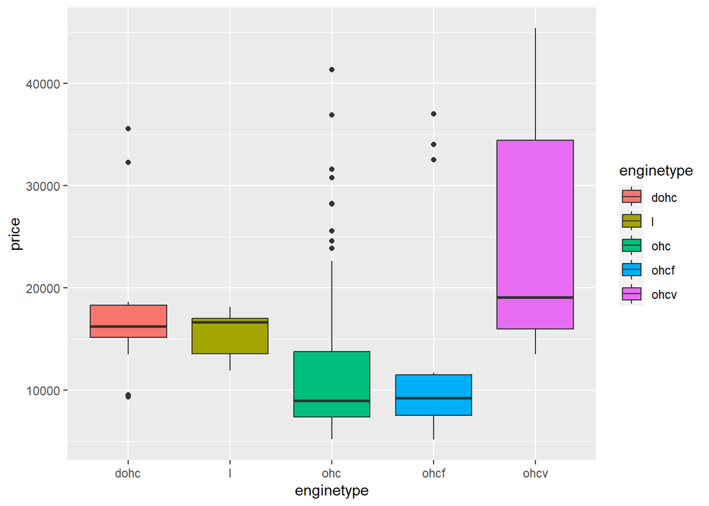

```r
ggplot(d, aes(x = enginetype, y = price, fill = enginetype)) +
       geom_boxplot( )
```

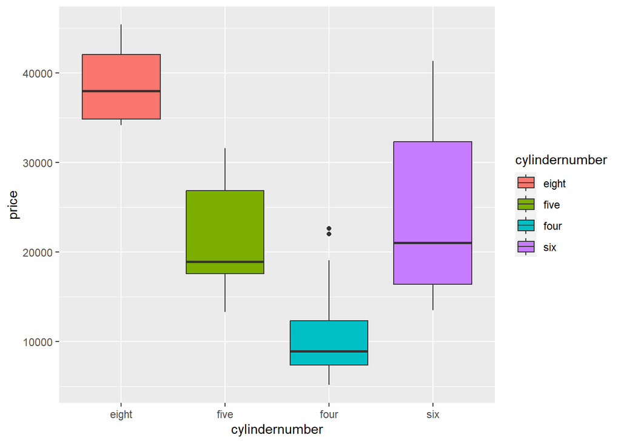

```r
ggplot(d, aes(x = cylindernumber, y = price, fill = cylindernumber)) +
       geom_boxplot( )
```

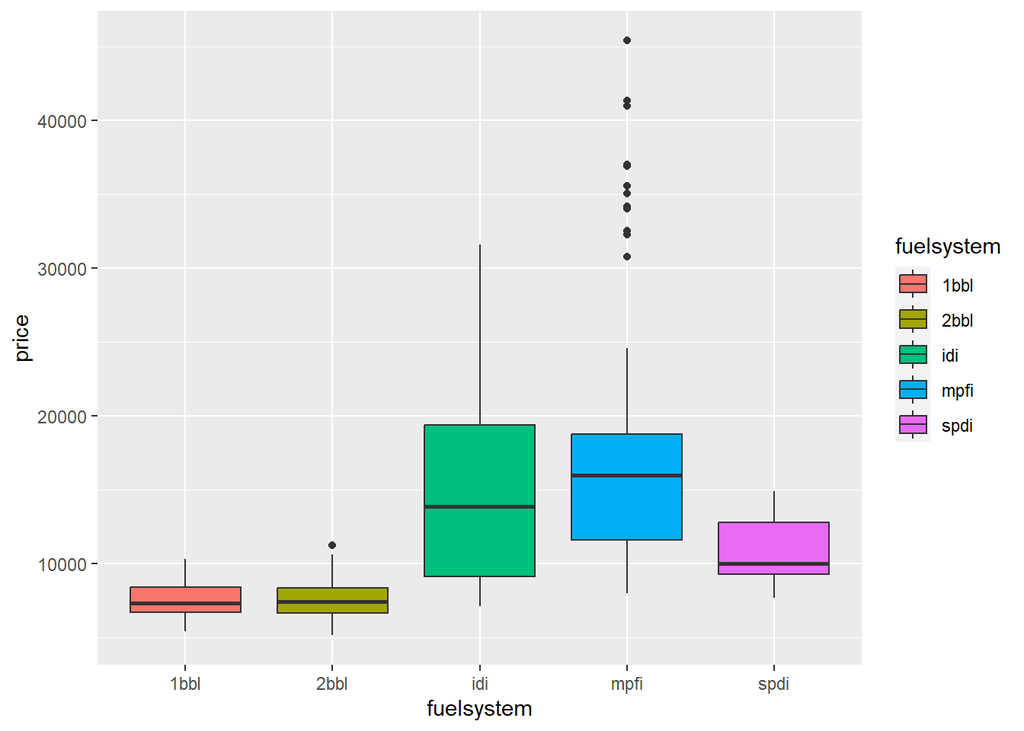

```r
ggplot(d, aes(x = fuelsystem, y = price, fill = fuelsystem)) +
       geom_boxplot( )
```

Alcuni livelli potrebbero essere assimilabili a causa della loro media che sembra statisticamente uguale. Si fa un ANOVA per verificarlo. Questo potrebbe semplificare decisamente la formulazione del modello e ridurre il numero di coefficienti significativi.

```r
d$symboling2 <- d$symboling
levels(d$symboling2) <- c("<0", "<0", "0", "<3", "<3", "3")
fit.symboling <- lm(price ~ symboling, data = d)
fit.symboling2 <- lm(price ~ symboling2, data = d)
anova(fit.symboling2,fit.symboling)
```

```
## Analysis of Variance Table
##
## Model 1: price ~ symboling2
## Model 2: price ~ symboling
##   Res.Df        RSS Df Sum of Sq      F Pr(>F)
## 1    192 1.0178e+10
## 2    190 1.0164e+10  2  13426009 0.1255 0.8821
```

Il test suggerisce che non c’è evidenza per concludere che le medie dei gruppi siano diverse.

```r
d$carbody2 <- d$carbody
levels(d$carbody2) <- c("ch", "ch", "h", "sw", "sw")
fit.carbody <- lm(price ~ carbody, data=d)
fit.carbody2 <- lm(price ~ carbody2, data=d)
anova(fit.carbody2,fit.carbody)
```

```
## Analysis of Variance Table
##
## Model 1: price ~ carbody2
## Model 2: price ~ carbody
##   Res.Df        RSS Df Sum of Sq      F Pr(>F)
## 1    193 1.0273e+10
## 2    191 1.0212e+10  2  60568341 0.5664 0.5685
```

Anche qui il test porta a considerare la nuova variabile.

```r
d$drivewheel2 <- d$drivewheel
levels(d$drivewheel2) <- c("4f", "4f", "r")
fit.drivewheel <- lm(price ~ drivewheel, data=d)
fit.drivewheel2 <- lm(price ~ drivewheel2, data=d)
anova(fit.drivewheel2,fit.drivewheel)
```

```
## Analysis of Variance Table
##
## Model 1: price ~ drivewheel2
## Model 2: price ~ drivewheel
##   Res.Df        RSS Df Sum of Sq      F Pr(>F)
## 1    194 6999993345
## 2    193 6971525933  1  28467412 0.7881 0.3758
```

```r
d$enginetype2 <- d$enginetype
levels(d$enginetype2) <- c("dl", "dl", "ohc", "ohc", "ohcv")
fit.enginetype <- lm(price ~ enginetype, data=d)
fit.enginetype2 <- lm(price ~ enginetype2, data=d)
anova(fit.enginetype2, fit.enginetype)
```

```
## Analysis of Variance Table
##
## Model 1: price ~ enginetype2
## Model 2: price ~ enginetype
##   Res.Df        RSS Df Sum of Sq      F Pr(>F)
## 1    193 1.0001e+10
## 2    191 9.8970e+09  2 103696716 1.0006 0.3696
```

```r
d$cylindernumber2 <- d$cylindernumber
levels(d$cylindernumber2) <- c("eight", "fivesix", "four", "fivesix")
fit.cylindernumber <- lm(price ~ cylindernumber, data=d)
fit.cylindernumber2 <- lm(price ~ cylindernumber2, data=d)
anova(fit.cylindernumber2,fit.cylindernumber)
```

```
## Analysis of Variance Table
##
## Model 1: price ~ cylindernumber2
## Model 2: price ~ cylindernumber
##   Res.Df        RSS Df Sum of Sq      F Pr(>F)
## 1    193 4709523584
## 2    192 4678091251  1  31432333 1.2901 0.2575
```

```r
d$fuelsystem2 <- d$fuelsystem
levels(d$fuelsystem2) <- c("12", "12", "im", "im", "s")
fit.fuelsystem <- lm(price ~ fuelsystem, data=d)
fit.fuelsystem2 <- lm(price ~ fuelsystem2, data=d)
anova(fit.fuelsystem2,fit.fuelsystem)
```

```
## Analysis of Variance Table
##
## Model 1: price ~ fuelsystem2
## Model 2: price ~ fuelsystem
##   Res.Df        RSS Df Sum of Sq      F Pr(>F)
## 1    193 7867285019
## 2    191 7825859680  2  41425338 0.5055  0.604
```

Tutti i test ci hanno portato ad assumere un numero minore di livelli (che diventano dunque anche più popolati e quindi fornenti risultati sperabilmente più stabili).

L’ultimo passo preparatorio è dunque rimuovere le variabili originali.

```r
d$symboling <- d$symboling2
d$carbody <- d$carbody2
d$drivewheel <- d$drivewheel2
d$enginetype <- d$enginetype2
d$cylindernumber <- d$cylindernumber2
d$ fuelsystem <- d$fuelsystem2
d <- d[,-c(21,22,23,24,25,26)]
```

## Formulazione del modello

Si definisce il modello con tutte le variabili come esplicative, si userà per lo scope nella stepwise regression tramite metrica AIC.

```r
fitAll <- lm(price ~ ., data=d)
summary(fitAll)
```

```
##
## Call:
## lm(formula = price ~ ., data = d)
##
## Residuals:
##     Min      1Q  Median      3Q     Max
## -6455.5 -1136.1  -102.2  1094.9 10623.2
##
## Coefficients:
##                         Estimate Std. Error t value Pr(>|t|)
## (Intercept)           -4.570e+04  1.311e+04  -3.487 0.000622 ***
## symboling0             1.317e+03  6.324e+02   2.083 0.038793 *
## symboling<3            8.200e+02  6.980e+02   1.175 0.241691
## symboling3             1.150e+03  1.087e+03   1.058 0.291670
## aspirationturbo        2.006e+03  8.288e+02   2.420 0.016565 *
## carbodyh              -9.896e+02  8.986e+02  -1.101 0.272319
## carbodysw              2.322e+01  9.316e+02   0.025 0.980140
## drivewheelr            2.121e+03  6.019e+02   3.524 0.000547 ***
## enginelocationrear     5.212e+03  2.045e+03   2.548 0.011708 *
## wheelbase              1.880e+01  9.792e+01   0.192 0.847931
## carlength             -3.082e+01  4.495e+01  -0.686 0.493957
## carwidth               7.933e+02  2.206e+02   3.595 0.000424 ***
## carheight              1.317e+02  1.183e+02   1.113 0.267170
## enginetypeohc          3.012e+03  6.833e+02   4.408 1.84e-05 ***
## enginetypeohcv        -5.022e+03  1.208e+03  -4.156 5.12e-05 ***
## cylindernumberfivesix -5.794e+03  2.146e+03  -2.700 0.007629 **
## cylindernumberfour    -6.732e+03  2.780e+03  -2.421 0.016515 *
## enginesize             1.504e+02  2.318e+01   6.488 9.12e-10 ***
## fuelsystemim           2.560e+02  6.035e+02   0.424 0.672024
## fuelsystems           -1.747e+03  1.121e+03  -1.558 0.121013
## boreratio             -4.486e+03  1.353e+03  -3.315 0.001122 **
## stroke                -3.768e+03  7.944e+02  -4.743 4.43e-06 ***
## compressionratio       8.162e+01  8.836e+01   0.924 0.356939
## horsepower             3.185e+01  2.115e+01   1.505 0.134052
## peakrpm                1.700e+00  5.638e-01   3.015 0.002966 **
## highwaympg             2.248e+01  6.647e+01   0.338 0.735656
## ---
## Signif. codes:  0 '***' 0.001 '**' 0.01 '*' 0.05 '.' 0.1 ' ' 1
##
## Residual standard error: 2308 on 170 degrees of freedom
## Multiple R-squared:  0.9251, Adjusted R-squared:  0.914
## F-statistic: 83.94 on 25 and 170 DF,  p-value: < 2.2e-16
```

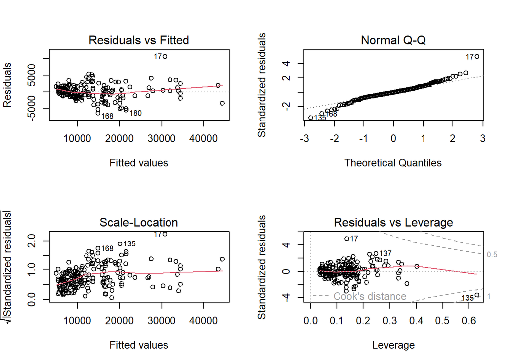

```r
par(mfrow=c(2,2))
plot(fitAll)
```

Risulta evidente nel grafico dei residui come siano violate le ipotesi di normalità, omoschedasticità e linearità. Si vede come sia necessaria una trasformazione.

```r
fitAllLog <- lm(log(price) ~ ., data=d)
summary(fitAllLog)
```

```
##
## Call:
## lm(formula = log(price) ~ ., data = d)
##
## Residuals:
##      Min       1Q   Median       3Q      Max
## -0.46685 -0.10239  0.00059  0.07991  0.37399
##
## Coefficients:
##                         Estimate Std. Error t value Pr(>|t|)
## (Intercept)            5.080e+00  8.446e-01   6.015 1.07e-08 ***
## symboling0             8.517e-02  4.075e-02   2.090 0.038095 *
## symboling<3            1.426e-02  4.498e-02   0.317 0.751622
## symboling3             1.578e-01  7.007e-02   2.252 0.025590 *
## aspirationturbo        8.031e-02  5.341e-02   1.504 0.134492
## carbodyh              -8.890e-02  5.790e-02  -1.535 0.126580
## carbodysw             -9.181e-03  6.003e-02  -0.153 0.878629
## drivewheelr            1.626e-01  3.878e-02   4.192 4.44e-05 ***
## enginelocationrear     1.571e-01  1.318e-01   1.192 0.234839
## wheelbase              1.227e-03  6.310e-03   0.194 0.846019
## carlength              2.580e-03  2.897e-03   0.891 0.374332
## carwidth               4.889e-02  1.422e-02   3.438 0.000736 ***
## carheight              5.039e-03  7.624e-03   0.661 0.509550
## enginetypeohc          1.690e-01  4.403e-02   3.838 0.000175 ***
## enginetypeohcv        -1.374e-01  7.786e-02  -1.765 0.079353 .
## cylindernumberfivesix -1.124e-01  1.383e-01  -0.813 0.417594
## cylindernumberfour    -2.070e-01  1.792e-01  -1.155 0.249613
## enginesize             4.014e-03  1.494e-03   2.687 0.007932 **
## fuelsystemim           1.232e-01  3.889e-02   3.167 0.001826 **
## fuelsystems           -2.316e-02  7.225e-02  -0.321 0.748907
## boreratio             -1.649e-01  8.721e-02  -1.891 0.060353 .
## stroke                -1.144e-01  5.119e-02  -2.236 0.026680 *
## compressionratio       5.554e-03  5.694e-03   0.976 0.330676
## horsepower             3.140e-03  1.363e-03   2.304 0.022454 *
## peakrpm                5.077e-05  3.633e-05   1.397 0.164120
## highwaympg            -4.199e-03  4.283e-03  -0.980 0.328243
## ---
## Signif. codes:  0 '***' 0.001 '**' 0.01 '*' 0.05 '.' 0.1 ' ' 1
##
## Residual standard error: 0.1487 on 170 degrees of freedom
## Multiple R-squared:  0.9227, Adjusted R-squared:  0.9114
## F-statistic: 81.21 on 25 and 170 DF,  p-value: < 2.2e-16
```

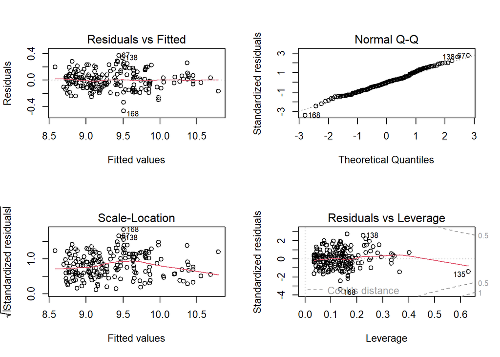

```r
par(mfrow=c(2,2))
plot(fitAllLog)
```

I residui del modello con le stesse esplicative per la trasformata logaritmica del prezzo risultano invece fedeli alle ipotesi del modello.

Si cerca con StepAIC un modello valido con meno esplicative.

```r
require(MASS)
fitEmpty <- lm(price ~ 1, data=d)
fitAIC <- stepAIC(fitEmpty, scope=formula(fitAll), direction="both")
```

```
## Start:  AIC=3517.69
## price ~ 1
##
##                    Df  Sum of Sq        RSS    AIC
## + enginesize        1 9572566027 2.5136e+09 3211.9
## + horsepower        1 7824378978 4.2618e+09 3315.4
## + cylindernumber    2 7376636697 4.7095e+09 3337.0
## + carwidth          1 6739435069 5.3467e+09 3359.8
## + highwaympg        1 6125442339 5.9607e+09 3381.1
## + carlength         1 5746787920 6.3394e+09 3393.2
## + drivewheel        1 5086166936 7.0000e+09 3412.6
## + wheelbase         1 4213513782 7.8726e+09 3435.7
## + fuelsystem        2 4218875263 7.8673e+09 3437.5
## + boreratio         1 3547402359 8.5388e+09 3451.6
## + enginetype        2 2085467438 1.0001e+10 3484.6
## + carbody           2 1813388415 1.0273e+10 3489.8
## + symboling         3 1908645539 1.0178e+10 3490.0
## + enginelocation    1 1395239528 1.0691e+10 3495.7
## + aspiration        1  469486100 1.1617e+10 3511.9
## + carheight         1  400819172 1.1685e+10 3513.1
## + stroke            1  144479491 1.1942e+10 3517.3
## + peakrpm           1  131093315 1.1955e+10 3517.6
## <none>                           1.2086e+10 3517.7
## + compressionratio  1   50884197 1.2035e+10 3518.9
##
## Step:  AIC=3211.91
## price ~ enginesize
##
##                    Df  Sum of Sq        RSS    AIC
## + enginelocation    1  271987309 2.2416e+09 3191.5
## + carwidth          1  218415594 2.2952e+09 3196.1
## + enginetype        2  240176465 2.2734e+09 3196.2
## + horsepower        1  211829996 2.3018e+09 3196.7
## + stroke            1  193313514 2.3203e+09 3198.2
## + fuelsystem        2  203402448 2.3102e+09 3199.4
## + drivewheel        1  149220971 2.3644e+09 3201.9
## + carbody           2  160491807 2.3531e+09 3203.0
## + peakrpm           1  136099743 2.3775e+09 3203.0
## + aspiration        1  116098778 2.3975e+09 3204.6
## + carlength         1  110327180 2.4033e+09 3205.1
```

[output cut: 278 more lines]

```
## + horsepower        1   1570673  946084738 3052.4
## + highwaympg        1    962965  946692446 3052.5
## + wheelbase         1    638108  947017303 3052.6
## + carlength         1    374275  947281137 3052.6
## - carbody           2  36091474  983746885 3054.0
## - fuelsystem        2  40137569  987792980 3054.8
## - drivewheel        1  63235496 1010890907 3061.4
## - boreratio         1  71375257 1019030668 3062.9
## - enginelocation    1  76427964 1024083376 3063.9
## - carwidth          1 107620540 1055275951 3069.8
## - peakrpm           1 121141608 1068797019 3072.3
## - aspiration        1 140257877 1087913289 3075.8
## - stroke            1 167400137 1115055548 3080.6
## - enginetype        2 359077967 1306733379 3109.7
## - enginesize        1 577099278 1524754689 3141.9
```

```r
summary(fitAIC)
```

```
##
## Call:
## lm(formula = price ~ enginesize + enginelocation + carwidth +
##     stroke + enginetype + boreratio + drivewheel + peakrpm +
##     aspiration + carbody + fuelsystem + cylindernumber, data = d)
##
## Residuals:
##     Min      1Q  Median      3Q     Max
## -6460.2 -1154.8   -84.6  1067.8 11234.0
##
## Coefficients:
##                         Estimate Std. Error t value Pr(>|t|)
## (Intercept)           -3.415e+04  1.032e+04  -3.310 0.001127 **
## enginesize             1.730e+02  1.657e+01  10.441  < 2e-16 ***
## enginelocationrear     6.807e+03  1.791e+03   3.800 0.000199 ***
## carwidth               7.000e+02  1.553e+02   4.509 1.18e-05 ***
## stroke                -4.095e+03  7.283e+02  -5.623 7.10e-08 ***
## enginetypeohc          2.671e+03  6.161e+02   4.336 2.42e-05 ***
## enginetypeohcv        -5.047e+03  1.089e+03  -4.634 6.88e-06 ***
## boreratio             -4.642e+03  1.264e+03  -3.672 0.000318 ***
## drivewheelr            1.869e+03  5.407e+02   3.456 0.000685 ***
## peakrpm                1.929e+00  4.032e-01   4.784 3.59e-06 ***
## aspirationturbo        2.846e+03  5.529e+02   5.147 6.92e-07 ***
## carbodyh              -8.715e+02  8.472e+02  -1.029 0.305020
## carbodysw              1.484e+02  7.960e+02   0.186 0.852296
## fuelsystemim           5.455e+02  4.985e+02   1.094 0.275285
## fuelsystems           -2.128e+03  1.006e+03  -2.116 0.035755 *
## cylindernumberfivesix -4.420e+03  1.970e+03  -2.244 0.026043 *
## cylindernumberfour    -5.325e+03  2.606e+03  -2.043 0.042502 *
## ---
## Signif. codes:  0 '***' 0.001 '**' 0.01 '*' 0.05 '.' 0.1 ' ' 1
##
## Residual standard error: 2301 on 179 degrees of freedom
## Multiple R-squared:  0.9216, Adjusted R-squared:  0.9146
## F-statistic: 131.5 on 16 and 179 DF,  p-value: < 2.2e-16
```

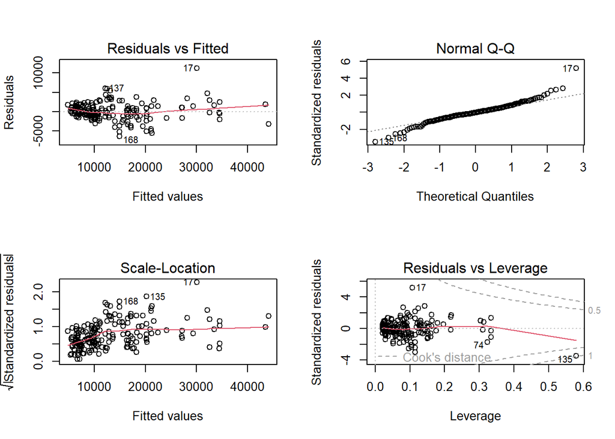

```r
par(mfrow=c(2,2))
plot(fitAIC)
```

Si osserva che carbody non sembra significativa

```r
fitNew <- lm(price ~ enginesize + enginelocation + carwidth +
    stroke + enginetype + boreratio + drivewheel + peakrpm +
    aspiration + fuelsystem + cylindernumber, data=d)
summary(fitNew)
```

```
##
## Call:
## lm(formula = price ~ enginesize + enginelocation + carwidth +
##     stroke + enginetype + boreratio + drivewheel + peakrpm +
##     aspiration + fuelsystem + cylindernumber, data = d)
##
## Residuals:
##     Min      1Q  Median      3Q     Max
## -6401.9 -1144.9  -120.1  1046.2 11422.0
##
## Coefficients:
##                         Estimate Std. Error t value Pr(>|t|)
## (Intercept)           -3.558e+04  1.034e+04  -3.442 0.000717 ***
## enginesize             1.689e+02  1.670e+01  10.117  < 2e-16 ***
## enginelocationrear     6.825e+03  1.702e+03   4.010 8.87e-05 ***
## carwidth               7.145e+02  1.539e+02   4.643 6.58e-06 ***
## stroke                -4.027e+03  7.368e+02  -5.466 1.51e-07 ***
## enginetypeohc          2.630e+03  6.237e+02   4.216 3.92e-05 ***
## enginetypeohcv        -5.408e+03  1.094e+03  -4.945 1.73e-06 ***
## boreratio             -4.160e+03  1.267e+03  -3.284 0.001229 **
## drivewheelr            1.830e+03  5.420e+02   3.377 0.000898 ***
## peakrpm                1.884e+00  4.076e-01   4.623 7.19e-06 ***
## aspirationturbo        2.761e+03  5.589e+02   4.940 1.77e-06 ***
## fuelsystemim           7.465e+02  4.937e+02   1.512 0.132239
## fuelsystems           -2.389e+03  1.014e+03  -2.356 0.019547 *
## cylindernumberfivesix -5.022e+03  1.939e+03  -2.590 0.010375 *
## cylindernumberfour    -6.204e+03  2.592e+03  -2.394 0.017701 *
## ---
## Signif. codes:  0 '***' 0.001 '**' 0.01 '*' 0.05 '.' 0.1 ' ' 1
##
## Residual standard error: 2331 on 181 degrees of freedom
## Multiple R-squared:  0.9186, Adjusted R-squared:  0.9123
## F-statistic: 145.9 on 14 and 181 DF,  p-value: < 2.2e-16
```

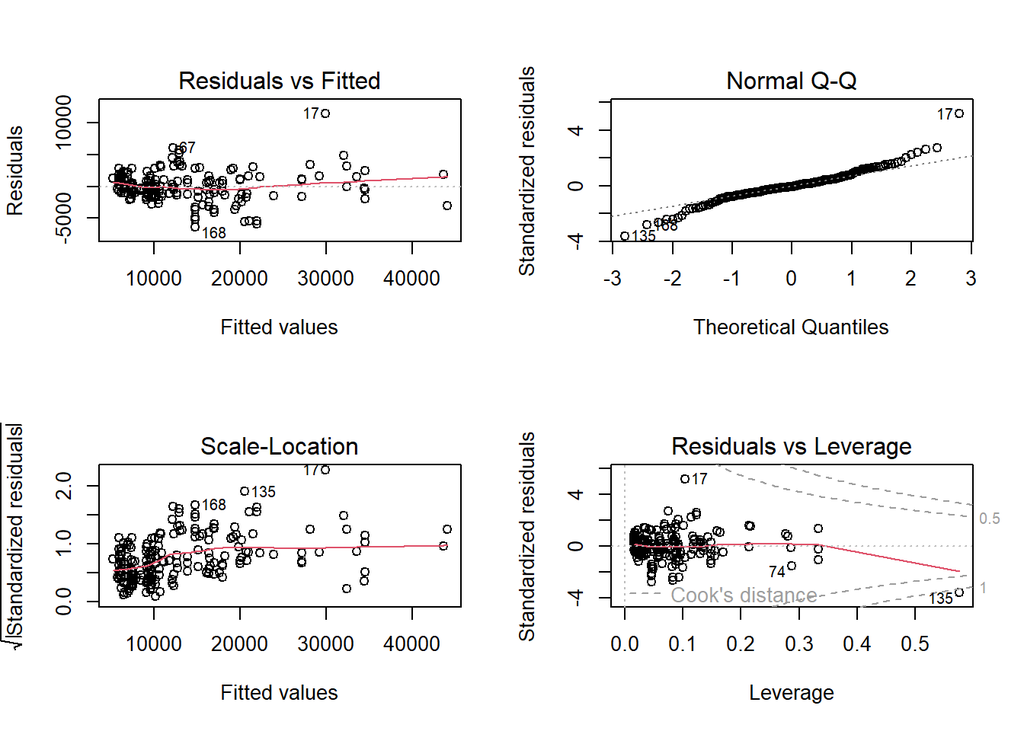

```r
par(mfrow=c(2,2))
plot(fitNew)
```

Si cerca una trasformazione.

```r
fitNewLog <- lm(log(price) ~ enginesize + enginelocation + carwidth +
    stroke + enginetype + boreratio + drivewheel + peakrpm +
    aspiration + fuelsystem + cylindernumber, data=d)
summary(fitNewLog)
```

```
##
## Call:
## lm(formula = log(price) ~ enginesize + enginelocation + carwidth +
##     stroke + enginetype + boreratio + drivewheel + peakrpm +
##     aspiration + fuelsystem + cylindernumber, data = d)
##
## Residuals:
##      Min       1Q   Median       3Q      Max
## -0.47130 -0.09708 -0.01498  0.08921  0.44427
##
## Coefficients:
##                         Estimate Std. Error t value Pr(>|t|)
## (Intercept)            4.653e+00  7.139e-01   6.517 6.91e-10 ***
## enginesize             7.566e-03  1.153e-03   6.559 5.50e-10 ***
## enginelocationrear     2.607e-01  1.176e-01   2.218 0.027801 *
## carwidth               5.879e-02  1.063e-02   5.531 1.10e-07 ***
## stroke                -2.048e-01  5.089e-02  -4.024 8.39e-05 ***
## enginetypeohc          1.033e-01  4.308e-02   2.399 0.017459 *
## enginetypeohcv        -2.174e-01  7.555e-02  -2.877 0.004493 **
## boreratio             -7.889e-02  8.750e-02  -0.902 0.368431
## drivewheelr            1.307e-01  3.744e-02   3.490 0.000607 ***
## peakrpm                1.087e-04  2.816e-05   3.861 0.000157 ***
## aspirationturbo        1.542e-01  3.860e-02   3.994 9.45e-05 ***
## fuelsystemim           1.954e-01  3.410e-02   5.730 4.12e-08 ***
## fuelsystems            3.517e-02  7.004e-02   0.502 0.616210
## cylindernumberfivesix  6.381e-02  1.339e-01   0.476 0.634353
## cylindernumberfour    -4.954e-02  1.790e-01  -0.277 0.782285
## ---
## Signif. codes:  0 '***' 0.001 '**' 0.01 '*' 0.05 '.' 0.1 ' ' 1
##
## Residual standard error: 0.161 on 181 degrees of freedom
## Multiple R-squared:  0.9036, Adjusted R-squared:  0.8961
## F-statistic: 121.2 on 14 and 181 DF,  p-value: < 2.2e-16
```

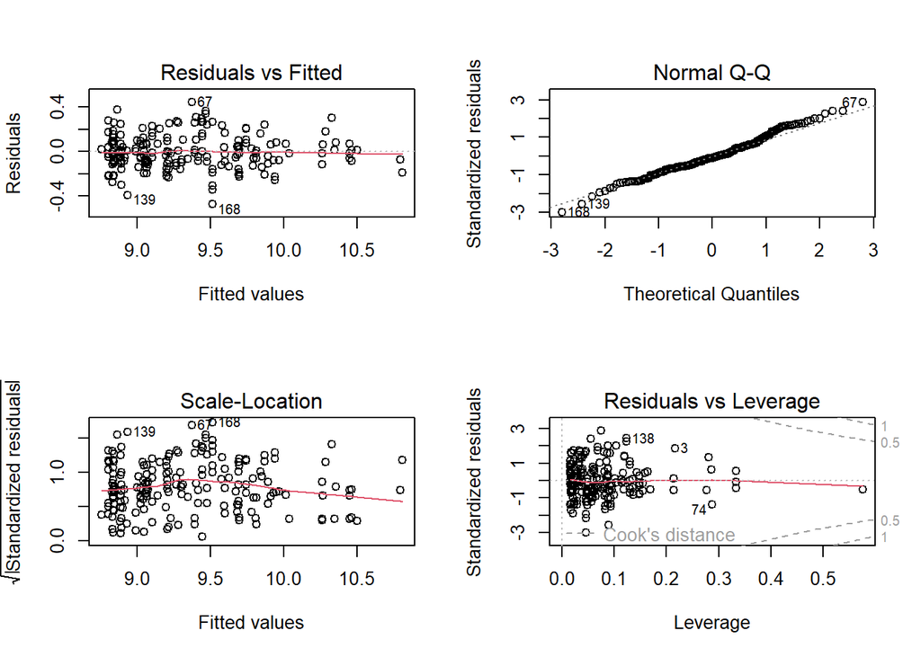

```r
par(mfrow=c(2,2))
plot(fitNewLog)
```

Si vuole tentare una via più efficiente targetizzando da subito il log(price) invece che price.

```r
fit0 <- lm(log(price) ~ ., data=d)
fit1 <- lm(log(price) ~ 1, data=d)
fit2 <- stepAIC(fit1, scope=formula(fit0), direction="both")
```

```
## Start:  AIC=-271
## log(price) ~ 1
##
##                    Df Sum of Sq    RSS     AIC
## + enginesize        1    35.686 12.994 -527.88
## + horsepower        1    33.847 14.832 -501.93
## + carwidth          1    30.600 18.080 -463.13
## + highwaympg        1    29.689 18.990 -453.50
## + carlength         1    29.148 19.531 -448.00
## + cylindernumber    2    25.151 23.528 -409.50
## + fuelsystem        2    24.735 23.944 -406.07
## + drivewheel        1    23.124 25.555 -395.31
## + wheelbase         1    20.003 28.677 -372.72
## + boreratio         1    17.417 31.263 -355.79
## + symboling         3    11.400 37.280 -317.30
## + enginetype        2     9.310 39.370 -308.60
## + carbody           2     7.016 41.663 -297.51
## + enginelocation    1     3.705 44.974 -284.52
## + aspiration        1     3.697 44.982 -284.48
## + carheight         1     2.582 46.097 -279.68
## + stroke            1     0.675 48.004 -271.74
## + peakrpm           1     0.644 48.036 -271.61
## <none>                          48.679 -271.00
## + compressionratio  1     0.351 48.328 -270.42
##
## Step:  AIC=-527.88
## log(price) ~ enginesize
##
##                    Df Sum of Sq    RSS     AIC
## + fuelsystem        2     4.006  8.988 -596.12
## + carlength         1     2.948 10.046 -576.31
## + carwidth          1     2.791 10.203 -573.27
## + horsepower        1     2.608 10.386 -569.78
## + highwaympg        1     2.531 10.462 -568.35
## + drivewheel        1     1.775 11.219 -554.66
## + aspiration        1     1.591 11.402 -551.48
## + wheelbase         1     1.347 11.647 -547.32
## + enginetype        2     1.172 11.822 -542.40
## + carbody           2     1.047 11.947 -540.34
## + carheight         1     0.900 12.094 -539.94
```

[output cut: 388 more lines]

```
## + aspiration        1   0.01222 3.9188 -728.82
## + carlength         1   0.00525 3.9258 -728.47
## + cylindernumber    2   0.03434 3.8967 -727.93
## - highwaympg        1   0.11523 4.0463 -726.54
## - fuelsystem        2   0.22512 4.1562 -723.29
## - symboling         3   0.28518 4.2162 -722.48
## - compressionratio  1   0.20599 4.1370 -722.20
## - stroke            1   0.24215 4.1732 -720.49
## - carbody           2   0.34735 4.2784 -717.61
## - drivewheel        1   0.37107 4.3021 -714.53
## - boreratio         1   0.38472 4.3158 -713.91
## - enginesize        1   0.61102 4.5421 -703.89
## - enginetype        2   0.89929 4.8303 -693.83
## - carwidth          1   0.88924 4.8203 -692.24
## - horsepower        1   0.90826 4.8393 -691.46
```

```r
summary(fit2)
```

```
##
## Call:
## lm(formula = log(price) ~ enginesize + fuelsystem + horsepower +
##     carwidth + carbody + enginetype + drivewheel + symboling +
##     compressionratio + stroke + boreratio + highwaympg, data = d)
##
## Residuals:
##      Min       1Q   Median       3Q      Max
## -0.50262 -0.09246 -0.00588  0.08259  0.33406
##
## Coefficients:
##                    Estimate Std. Error t value Pr(>|t|)
## (Intercept)       5.3966766  0.6920379   7.798 5.09e-13 ***
## enginesize        0.0040808  0.0007758   5.260 4.10e-07 ***
## fuelsystemim      0.0996731  0.0362503   2.750  0.00658 **
## fuelsystems      -0.0325984  0.0642455  -0.507  0.61250
## horsepower        0.0049103  0.0007657   6.413 1.24e-09 ***
## carwidth          0.0623850  0.0098314   6.345 1.78e-09 ***
## carbodyh         -0.1114226  0.0519136  -2.146  0.03320 *
## carbodysw        -0.0032561  0.0531230  -0.061  0.95119
## enginetypeohc     0.1748643  0.0406462   4.302 2.79e-05 ***
## enginetypeohcv   -0.1530921  0.0662281  -2.312  0.02195 *
## drivewheelr       0.1494563  0.0364613   4.099 6.30e-05 ***
## symboling0        0.0782913  0.0384688   2.035  0.04331 *
## symboling<3       0.0092163  0.0406044   0.227  0.82070
## symboling3        0.1311169  0.0575542   2.278  0.02391 *
## compressionratio  0.0121197  0.0039684   3.054  0.00260 **
## stroke           -0.1429638  0.0431748  -3.311  0.00112 **
## boreratio        -0.2508623  0.0601045  -4.174 4.68e-05 ***
## highwaympg       -0.0082509  0.0036121  -2.284  0.02354 *
## ---
## Signif. codes:  0 '***' 0.001 '**' 0.01 '*' 0.05 '.' 0.1 ' ' 1
##
## Residual standard error: 0.1486 on 178 degrees of freedom
## Multiple R-squared:  0.9192, Adjusted R-squared:  0.9115
## F-statistic: 119.2 on 17 and 178 DF,  p-value: < 2.2e-16
```

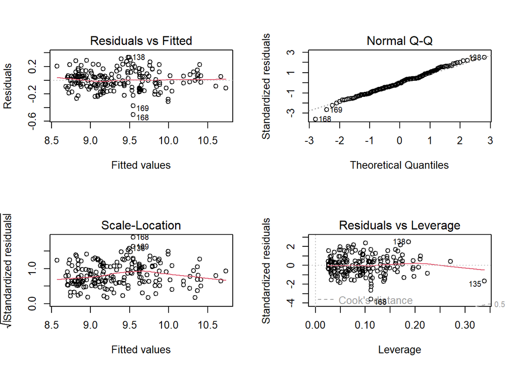

```r
par(mfrow=c(2,2))
plot(fit2)
```

I risultati sembrano decisamente migliorati.

Possibili multicollinearità: horsepower e enginesize. Si rimuove horsepower in virtù del fatto che è meno correlata con price.

```r
fit3 <- lm(log(price) ~ enginesize + fuelsystem +
    carwidth + carbody + enginetype + drivewheel + symboling +
    compressionratio + stroke + boreratio + highwaympg, data=d)
summary(fit3)
```

```
##
## Call:
## lm(formula = log(price) ~ enginesize + fuelsystem + carwidth +
##     carbody + enginetype + drivewheel + symboling + compressionratio +
##     stroke + boreratio + highwaympg, data = d)
##
## Residuals:
##      Min       1Q   Median       3Q      Max
## -0.52118 -0.08448 -0.00298  0.09274  0.58166
##
## Coefficients:
##                   Estimate Std. Error t value Pr(>|t|)
## (Intercept)       6.288976   0.750050   8.385 1.47e-14 ***
## enginesize        0.006541   0.000746   8.768 1.38e-15 ***
## fuelsystemim      0.185519   0.037273   4.977 1.51e-06 ***
## fuelsystems       0.046088   0.069774   0.661 0.509759
## carwidth          0.054837   0.010799   5.078 9.53e-07 ***
## carbodyh         -0.078197   0.057152  -1.368 0.172951
## carbodysw         0.021982   0.058615   0.375 0.708091
## enginetypeohc     0.184811   0.044939   4.112 5.96e-05 ***
## enginetypeohcv   -0.156839   0.073273  -2.140 0.033671 *
## drivewheelr       0.176824   0.040064   4.414 1.75e-05 ***
## symboling0        0.059076   0.042433   1.392 0.165587
## symboling<3       0.004918   0.044920   0.109 0.912941
## symboling3        0.197843   0.062630   3.159 0.001859 **
## compressionratio  0.003755   0.004147   0.905 0.366458
## stroke           -0.147865   0.047762  -3.096 0.002278 **
## boreratio        -0.250786   0.066501  -3.771 0.000221 ***
## highwaympg       -0.014667   0.003840  -3.819 0.000184 ***
## ---
## Signif. codes:  0 '***' 0.001 '**' 0.01 '*' 0.05 '.' 0.1 ' ' 1
##
## Residual standard error: 0.1644 on 179 degrees of freedom
## Multiple R-squared:  0.9006, Adjusted R-squared:  0.8917
## F-statistic: 101.3 on 16 and 179 DF,  p-value: < 2.2e-16
```

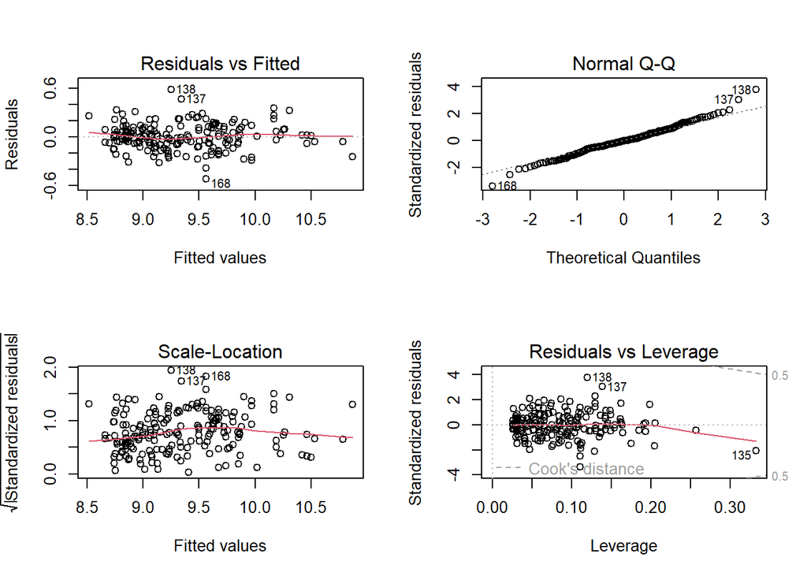

```r
par(mfrow=c(2,2))
plot(fit3)
```

Ancora una volta carbody non è significativa nel modello.

```r
fit4 <- lm(log(price) ~ enginesize + fuelsystem +
    carwidth + enginetype + drivewheel + symboling +
    stroke + boreratio + highwaympg, data=d)
summary(fit4)
```

```
##
## Call:
## lm(formula = log(price) ~ enginesize + fuelsystem + carwidth +
##     enginetype + drivewheel + symboling + stroke + boreratio +
##     highwaympg, data = d)
##
## Residuals:
##      Min       1Q   Median       3Q      Max
## -0.51832 -0.10345 -0.00372  0.09681  0.60641
##
## Coefficients:
##                  Estimate Std. Error t value Pr(>|t|)
## (Intercept)     6.1434610  0.7130589   8.616 3.28e-15 ***
## enginesize      0.0067925  0.0007429   9.143  < 2e-16 ***
## fuelsystemim    0.2207848  0.0352021   6.272 2.53e-09 ***
## fuelsystems     0.0480827  0.0706711   0.680 0.497133
## carwidth        0.0564719  0.0102368   5.517 1.17e-07 ***
## enginetypeohc   0.1805417  0.0455640   3.962 0.000106 ***
## enginetypeohcv -0.1885309  0.0744007  -2.534 0.012120 *
## drivewheelr     0.1731969  0.0402420   4.304 2.74e-05 ***
## symboling0      0.0597895  0.0433626   1.379 0.169640
## symboling<3    -0.0259203  0.0437753  -0.592 0.554505
## symboling3      0.1273661  0.0559233   2.278 0.023918 *
## stroke         -0.1568378  0.0482172  -3.253 0.001362 **
## boreratio      -0.2479127  0.0678301  -3.655 0.000336 ***
## highwaympg     -0.0127273  0.0031262  -4.071 6.97e-05 ***
## ---
## Signif. codes:  0 '***' 0.001 '**' 0.01 '*' 0.05 '.' 0.1 ' ' 1
##
## Residual standard error: 0.1684 on 182 degrees of freedom
## Multiple R-squared:  0.894,  Adjusted R-squared:  0.8864
## F-statistic: 118.1 on 13 and 182 DF,  p-value: < 2.2e-16
```

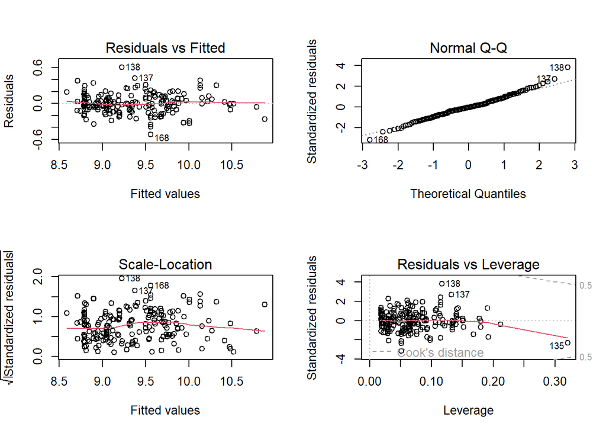

```r
par(mfrow=c(2,2))
plot(fit4)
```

```r
fit5 <- lm(log(price) ~ enginesize + fuelsystem + carwidth +
    enginetype + drivewheel + symboling +
    highwaympg, data = d)
summary(fit5)
```

```
##
## Call:
## lm(formula = log(price) ~ enginesize + fuelsystem + carwidth +
##     enginetype + drivewheel + symboling + highwaympg, data = d)
##
## Residuals:
##      Min       1Q   Median       3Q      Max
## -0.58991 -0.09493 -0.00328  0.10267  0.56114
##
## Coefficients:
##                  Estimate Std. Error t value Pr(>|t|)
## (Intercept)     5.2912125  0.7124033   7.427 4.01e-12 ***
## enginesize      0.0053028  0.0006741   7.866 3.01e-13 ***
## fuelsystemim    0.2059591  0.0365869   5.629 6.66e-08 ***
## fuelsystems    -0.0289103  0.0696087  -0.415  0.67839
## carwidth        0.0524020  0.0106450   4.923 1.89e-06 ***
## enginetypeohc   0.1656197  0.0472304   3.507  0.00057 ***
## enginetypeohcv -0.0909356  0.0738408  -1.232  0.21970
## drivewheelr     0.1632804  0.0401893   4.063 7.17e-05 ***
## symboling0      0.0674015  0.0451037   1.494  0.13679
## symboling<3    -0.0053050  0.0453313  -0.117  0.90697
## symboling3      0.1636100  0.0573980   2.850  0.00486 **
## highwaympg     -0.0133609  0.0031302  -4.268 3.15e-05 ***
## ---
## Signif. codes:  0 '***' 0.001 '**' 0.01 '*' 0.05 '.' 0.1 ' ' 1
##
## Residual standard error: 0.1759 on 184 degrees of freedom
## Multiple R-squared:  0.8831, Adjusted R-squared:  0.8761
## F-statistic: 126.3 on 11 and 184 DF,  p-value: < 2.2e-16
```

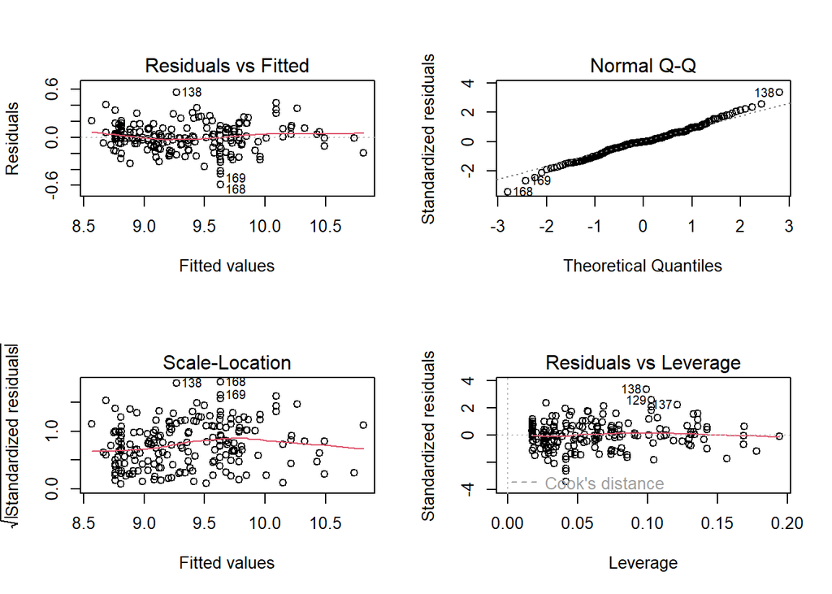

```r
par(mfrow=c(2,2))
plot(fit5)
```

```r
shapiro.test(fit5$residuals)
```

```
##
##  Shapiro-Wilk normality test
##
## data:  fit5$residuals
## W = 0.99015, p-value = 0.1995
```